# 과제12 회귀 분석

Joey Choi

2019 6 28

### 1. 부모의 키가 클수록 자식의 키도 상대적으로 크다고 하는데, 아버지의 키와 아들의 키를 조사하였더니 아래와 같이 나왔다고 한다. 이 자료를 바탕으로 해서 회귀식을 구하고 아버지의 키가 165cm일 때 아들의 키는 얼마인지 예측하시오.

#아버지의 키(x): 150 160 170 180 190 #아들의 키(y): 176 179 182 181 185

```r
x <- c(150,160,170,180,190)
y <- c(176,179,182,181,185)
height <- data.frame(x,y)
names(height) <- c("Dad", "Son")
cor_height <- lm(Son ~ Dad, data = height)
cor_height
```

```
##
## Call:
## lm(formula = Son ~ Dad, data = height)
##
## Coefficients:
## (Intercept)          Dad
##       146.6          0.2
```

```r
par(mfrow=c(2,2))
plot(cor_height)
summary(cor_height)
```

```
##
## Call:
## lm(formula = Son ~ Dad, data = height)
##
## Residuals:
##    1    2    3    4    5
## -0.6  0.4  1.4 -1.6  0.4
##
## Coefficients:
##              Estimate Std. Error t value Pr(>|t|)
## (Intercept) 146.60000    7.10211  20.642 0.000249 ***
## Dad           0.20000    0.04163   4.804 0.017171 *
## ---
## Signif. codes:  0 '***' 0.001 '**' 0.01 '*' 0.05 '.' 0.1 ' ' 1
##
## Residual standard error: 1.317 on 3 degrees of freedom
## Multiple R-squared:  0.885,  Adjusted R-squared:  0.8466
## F-statistic: 23.08 on 1 and 3 DF,  p-value: 0.01717
```

```r
library(psych)
```

[figure not shown]

```r
#pairs.panels(height[names(height)])

pre <- predict(cor_height,newdata = height )
pre <- as.data.frame(pre)
predict(cor_height, )
```

```
##     1     2     3     4     5
## 176.6 178.6 180.6 182.6 184.6
```

```r
test <- as.data.frame(165)
data <- c(150,160,170,180,190)
test2 <- data.frame("Dad" = data)
names(test) <- "Dad"
pre.ans <- predict(cor_height,test)
pre.test <- predict(cor_height,test2)
#예측치
cor(pre.test,y)
```

```
## [1] 0.9407209
```

```r
#아버지의 키가 165 일 경우 아들의 키 예측
pre.ans <- predict(cor_height,test)
pre.ans
```

```
##     1
## 179.6
```

### 2. 소득이 높을수록 신용카드 사용량이 많아진다고 하는데, 월 소득 대비 신용카드 사용량을 조사하였더니 아래와 같이 나왔다고 한다. 이 자료를 바탕으로 해서 회귀식을 구하고, 월 소득이 250만원일 때 신용카드 사용량을 예측하시오. (단위: 만원)

#### 월 소득(x): 100 200 300 400 500

#### 카드 사용량(y): 30 70 85 140 197

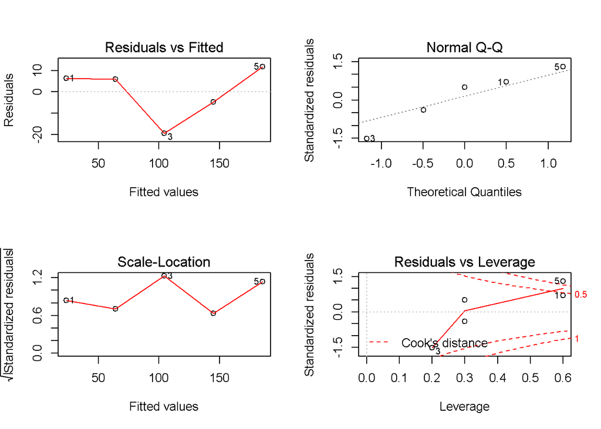

```r
x <- c(100,200,300,400,500)
y <- c(30,70,85,140,197)
cc <- data.frame(Income = x, Usage = y)
cor_cc <- lm(Usage ~ Income, data = cc)
par(mfrow = c(2,2))
plot(cor_cc)
```

```r
summary(cor_cc)
```

```
##
## Call:
## lm(formula = Usage ~ Income, data = cc)
##
## Residuals:
##     1     2     3     4     5
##   6.4   6.0 -19.4  -4.8  11.8
##
## Coefficients:
##             Estimate Std. Error t value Pr(>|t|)
## (Intercept) -16.8000    15.0240  -1.118  0.34495
## Income        0.4040     0.0453   8.919  0.00297 **
## ---
## Signif. codes:  0 '***' 0.001 '**' 0.01 '*' 0.05 '.' 0.1 ' ' 1
##
## Residual standard error: 14.32 on 3 degrees of freedom
## Multiple R-squared:  0.9637, Adjusted R-squared:  0.9515
## F-statistic: 79.54 on 1 and 3 DF,  p-value: 0.002974
```

```r
test <- data.frame(Income = 250)
pre.ans <- predict(cor_cc,test)

#예측값
pre.ans
```

```
##    1
## 84.2
```

### 3. mtcars 데이터셋에서 배기량(disp)에 따른 마력(hp)의 회귀식을 구하시오.

```r
str(mtcars)
```

```
## 'data.frame':    32 obs. of  11 variables:
##  $ mpg : num  21 21 22.8 21.4 18.7 18.1 14.3 24.4 22.8 19.2 ...
##  $ cyl : num  6 6 4 6 8 6 8 4 4 6 ...
##  $ disp: num  160 160 108 258 360 ...
##  $ hp  : num  110 110 93 110 175 105 245 62 95 123 ...
##  $ drat: num  3.9 3.9 3.85 3.08 3.15 2.76 3.21 3.69 3.92 3.92 ...
##  $ wt  : num  2.62 2.88 2.32 3.21 3.44 ...
##  $ qsec: num  16.5 17 18.6 19.4 17 ...
##  $ vs  : num  0 0 1 1 0 1 0 1 1 1 ...
##  $ am  : num  1 1 1 0 0 0 0 0 0 0 ...
##  $ gear: num  4 4 4 3 3 3 3 4 4 4 ...
##  $ carb: num  4 4 1 1 2 1 4 2 2 4 ...
```

```r
head(mtcars)
```

```
##                    mpg cyl disp  hp drat    wt  qsec vs am gear carb
## Mazda RX4         21.0   6  160 110 3.90 2.620 16.46  0  1    4    4
## Mazda RX4 Wag     21.0   6  160 110 3.90 2.875 17.02  0  1    4    4
## Datsun 710        22.8   4  108  93 3.85 2.320 18.61  1  1    4    1
## Hornet 4 Drive    21.4   6  258 110 3.08 3.215 19.44  1  0    3    1
## Hornet Sportabout 18.7   8  360 175 3.15 3.440 17.02  0  0    3    2
## Valiant           18.1   6  225 105 2.76 3.460 20.22  1  0    3    1
```

```r
# 종속 변수
y <- mtcars$hp
# 독립 변수
x <- mtcars$disp

df <- data.frame(disp = x, hp = y)
result.lm <- lm(hp ~ disp, data= df)
result.lm2 <- lm(hp ~ ., data = mtcars)
result.lm3 <- lm(hp ~ disp + wt + carb, data = mtcars)
summary(result.lm2)
```

```
##
## Call:
## lm(formula = hp ~ ., data = mtcars)
##
## Residuals:
##     Min      1Q  Median      3Q     Max
## -38.681 -15.558   0.799  18.106  34.718
##
## Coefficients:
##             Estimate Std. Error t value Pr(>|t|)
## (Intercept)  79.0484   184.5041   0.428  0.67270
## mpg          -2.0631     2.0906  -0.987  0.33496
## cyl           8.2037    10.0861   0.813  0.42513
## disp          0.4390     0.1492   2.942  0.00778 **
## drat         -4.6185    16.0829  -0.287  0.77680
## wt          -27.6600    19.2704  -1.435  0.16591
## qsec         -1.7844     7.3639  -0.242  0.81089
## vs           25.8129    19.8512   1.300  0.20758
## am            9.4863    20.7599   0.457  0.65240
## gear          7.2164    14.6160   0.494  0.62662
## carb         18.7487     7.0288   2.667  0.01441 *
## ---
## Signif. codes:  0 '***' 0.001 '**' 0.01 '*' 0.05 '.' 0.1 ' ' 1
##
## Residual standard error: 25.97 on 21 degrees of freedom
## Multiple R-squared:  0.9028, Adjusted R-squared:  0.8565
## F-statistic:  19.5 on 10 and 21 DF,  p-value: 1.898e-08
```

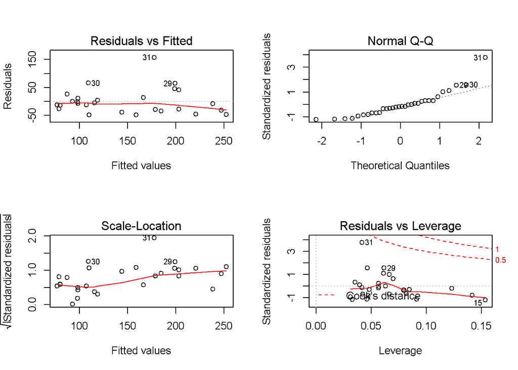

```r
par(mfrow=c(2,2))
plot(result.lm)
```

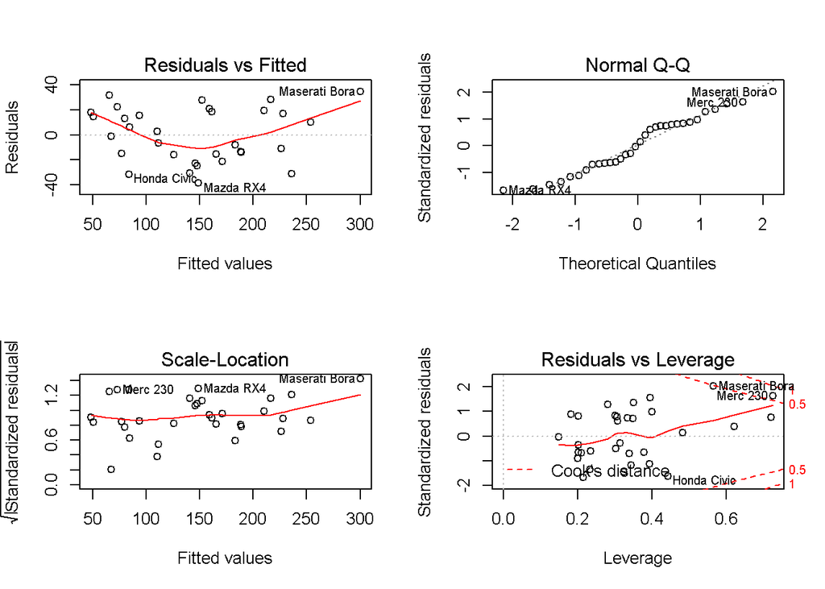

```r
plot(result.lm2)
```

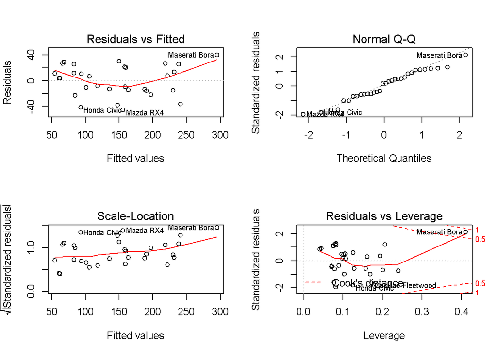

```r
plot(result.lm3)
```

```r
par(mfrow=c(1,1))
step(result.lm2, direction = 'backward')
```

```
## Start:  AIC=216.97
## hp ~ mpg + cyl + disp + drat + wt + qsec + vs + am + gear + carb
##
##        Df Sum of Sq   RSS    AIC
## - qsec  1      39.6 14204 215.06
## - drat  1      55.6 14220 215.09
## - am    1     140.8 14306 215.28
## - gear  1     164.4 14329 215.34
## - cyl   1     446.2 14611 215.96
## - mpg   1     656.9 14822 216.42
## <none>              14165 216.97
## - vs    1    1140.5 15305 217.45
## - wt    1    1389.7 15554 217.96
## - carb  1    4799.2 18964 224.31
## - disp  1    5839.6 20004 226.01
##
## Step:  AIC=215.06
## hp ~ mpg + cyl + disp + drat + wt + vs + am + gear + carb
##
##        Df Sum of Sq   RSS    AIC
## - drat  1      50.6 14255 213.17
## - gear  1     184.3 14389 213.47
## - am    1     216.7 14421 213.54
## - cyl   1     565.0 14769 214.31
## - mpg   1     793.5 14998 214.80
## <none>              14204 215.06
## - vs    1    1133.8 15338 215.52
## - wt    1    2577.3 16782 218.39
## - carb  1    5653.2 19858 223.78
## - disp  1    7460.7 21665 226.57
##
## Step:  AIC=213.17
## hp ~ mpg + cyl + disp + wt + vs + am + gear + carb
##
##        Df Sum of Sq   RSS    AIC
## - gear  1     172.8 14428 211.56
## - am    1     191.5 14446 211.60
## - cyl   1     722.9 14978 212.75
## - mpg   1     848.4 15103 213.02
## <none>              14255 213.17
```

[output cut: 44 more lines]

```
##        Df Sum of Sq   RSS    AIC
## - mpg   1     856.1 16564 207.98
## <none>              15708 208.28
## - wt    1    5792.6 21501 216.32
## - disp  1   20461.9 36170 232.97
## - carb  1   26384.0 42092 237.82
##
## Step:  AIC=207.98
## hp ~ disp + wt + carb
##
##        Df Sum of Sq   RSS    AIC
## <none>              16564 207.98
## - wt    1      4961 21525 214.36
## - disp  1     26844 43408 236.81
## - carb  1     36686 53250 243.34
```

```
##
## Call:
## lm(formula = hp ~ disp + wt + carb, data = mtcars)
##
## Coefficients:
## (Intercept)         disp           wt         carb
##     53.1671       0.5166     -28.5921      23.5769
```

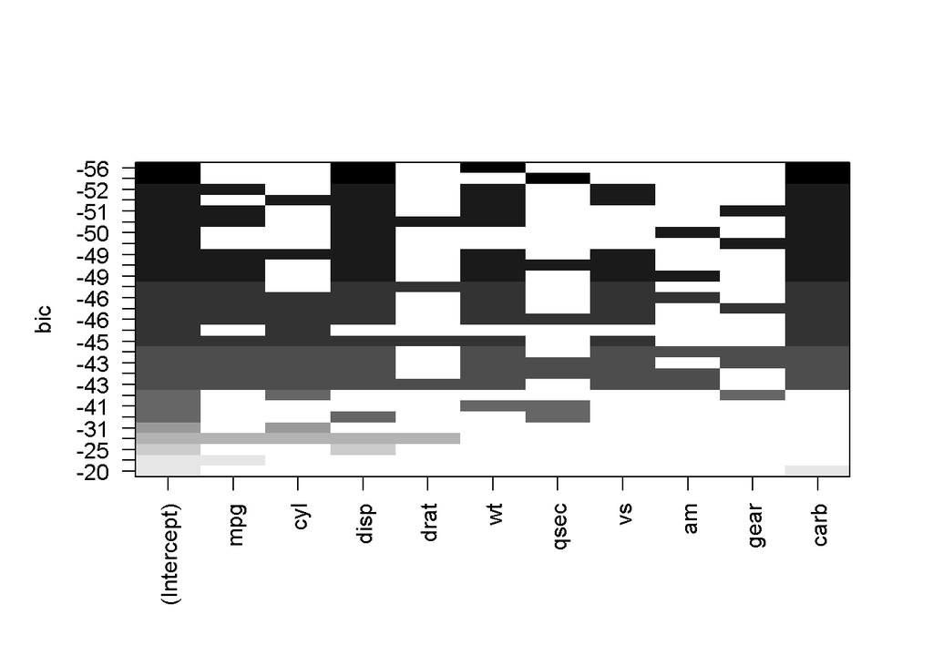

```r
subsets1 <- regsubsets(hp~., data = mtcars,
                      method = 'seqrep', nbest=4)
subsets2 <- regsubsets(hp~., data= mtcars,
                      method='exhaustive',nbest=4)
plot(subsets1)
```

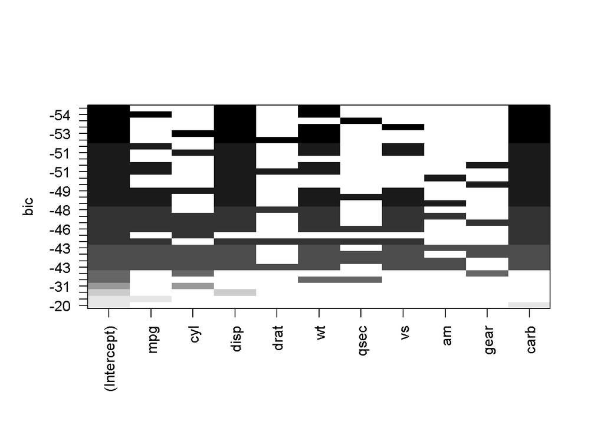

```r
plot(subsets2)
```

```r
final.lm <- lm(hp ~ disp + wt + carb, data = mtcars)
summary(final.lm)
```

```
##
## Call:
## lm(formula = hp ~ disp + wt + carb, data = mtcars)
##
## Residuals:
##     Min      1Q  Median      3Q     Max
## -45.225 -14.235   3.879  20.621  39.785
##
## Coefficients:
##              Estimate Std. Error t value Pr(>|t|)
## (Intercept)  53.16715   18.16036   2.928  0.00671 **
## disp          0.51663    0.07669   6.736 2.59e-07 ***
## wt          -28.59214    9.87292  -2.896  0.00725 **
## carb         23.57691    2.99391   7.875 1.41e-08 ***
## ---
## Signif. codes:  0 '***' 0.001 '**' 0.01 '*' 0.05 '.' 0.1 ' ' 1
##
## Residual standard error: 24.32 on 28 degrees of freedom
## Multiple R-squared:  0.8863, Adjusted R-squared:  0.8742
## F-statistic: 72.78 on 3 and 28 DF,  p-value: 2.462e-13
```

### 4. MASS 패키지를 설치하고, 이 패키지 안에 있는 Boston 데이터셋을 이용하여 Boston 인근의 집값을 결정하는 다중회귀 모델을 만드시오.

```r
str(Boston)
```

```
## 'data.frame':    506 obs. of  14 variables:
##  $ crim   : num  0.00632 0.02731 0.02729 0.03237 0.06905 ...
##  $ zn     : num  18 0 0 0 0 0 12.5 12.5 12.5 12.5 ...
##  $ indus  : num  2.31 7.07 7.07 2.18 2.18 2.18 7.87 7.87 7.87 7.87 ...
##  $ chas   : int  0 0 0 0 0 0 0 0 0 0 ...
##  $ nox    : num  0.538 0.469 0.469 0.458 0.458 0.458 0.524 0.524 0.524 0.524 ...
##  $ rm     : num  6.58 6.42 7.18 7 7.15 ...
##  $ age    : num  65.2 78.9 61.1 45.8 54.2 58.7 66.6 96.1 100 85.9 ...
##  $ dis    : num  4.09 4.97 4.97 6.06 6.06 ...
##  $ rad    : int  1 2 2 3 3 3 5 5 5 5 ...
##  $ tax    : num  296 242 242 222 222 222 311 311 311 311 ...
##  $ ptratio: num  15.3 17.8 17.8 18.7 18.7 18.7 15.2 15.2 15.2 15.2 ...
##  $ black  : num  397 397 393 395 397 ...
##  $ lstat  : num  4.98 9.14 4.03 2.94 5.33 ...
##  $ medv   : num  24 21.6 34.7 33.4 36.2 28.7 22.9 27.1 16.5 18.9 ...
```

```r
head(Boston)
```

```
##      crim zn indus chas   nox    rm  age    dis rad tax ptratio  black
## 1 0.00632 18  2.31    0 0.538 6.575 65.2 4.0900   1 296    15.3 396.90
## 2 0.02731  0  7.07    0 0.469 6.421 78.9 4.9671   2 242    17.8 396.90
## 3 0.02729  0  7.07    0 0.469 7.185 61.1 4.9671   2 242    17.8 392.83
## 4 0.03237  0  2.18    0 0.458 6.998 45.8 6.0622   3 222    18.7 394.63
## 5 0.06905  0  2.18    0 0.458 7.147 54.2 6.0622   3 222    18.7 396.90
## 6 0.02985  0  2.18    0 0.458 6.430 58.7 6.0622   3 222    18.7 394.12
##   lstat medv
## 1  4.98 24.0
## 2  9.14 21.6
## 3  4.03 34.7
## 4  2.94 33.4
## 5  5.33 36.2
## 6  5.21 28.7
```

```r
#View(Boston)

data <- Boston
set.seed(1234)
#pairs(~., data=data)
#pairs.panels(data)

#pairs(data %>% dplyr::sample_n(min(1000, nrow(data))),      lower.panel=function(x,y){ points(x,y); abline(0, 1, col='red')})

data_lm_full <- lm(medv ~ ., data= data)
summary(data_lm_full)
```

```
##
## Call:
## lm(formula = medv ~ ., data = data)
##
## Residuals:
##     Min      1Q  Median      3Q     Max
## -15.595  -2.730  -0.518   1.777  26.199
##
## Coefficients:
##               Estimate Std. Error t value Pr(>|t|)
## (Intercept)  3.646e+01  5.103e+00   7.144 3.28e-12 ***
## crim        -1.080e-01  3.286e-02  -3.287 0.001087 **
## zn           4.642e-02  1.373e-02   3.382 0.000778 ***
## indus        2.056e-02  6.150e-02   0.334 0.738288
## chas         2.687e+00  8.616e-01   3.118 0.001925 **
## nox         -1.777e+01  3.820e+00  -4.651 4.25e-06 ***
## rm           3.810e+00  4.179e-01   9.116  < 2e-16 ***
## age          6.922e-04  1.321e-02   0.052 0.958229
## dis         -1.476e+00  1.995e-01  -7.398 6.01e-13 ***
## rad          3.060e-01  6.635e-02   4.613 5.07e-06 ***
## tax         -1.233e-02  3.760e-03  -3.280 0.001112 **
## ptratio     -9.527e-01  1.308e-01  -7.283 1.31e-12 ***
## black        9.312e-03  2.686e-03   3.467 0.000573 ***
## lstat       -5.248e-01  5.072e-02 -10.347  < 2e-16 ***
## ---
## Signif. codes:  0 '***' 0.001 '**' 0.01 '*' 0.05 '.' 0.1 ' ' 1
##
## Residual standard error: 4.745 on 492 degrees of freedom
## Multiple R-squared:  0.7406, Adjusted R-squared:  0.7338
## F-statistic: 108.1 on 13 and 492 DF,  p-value: < 2.2e-16
```

```r
data_step <- step(data_lm_full, direction = "backward")
```

```
## Start:  AIC=1589.64
## medv ~ crim + zn + indus + chas + nox + rm + age + dis + rad +
##     tax + ptratio + black + lstat
##
##           Df Sum of Sq   RSS    AIC
## - age      1      0.06 11079 1587.7
## - indus    1      2.52 11081 1587.8
## <none>                 11079 1589.6
## - chas     1    218.97 11298 1597.5
## - tax      1    242.26 11321 1598.6
## - crim     1    243.22 11322 1598.6
## - zn       1    257.49 11336 1599.3
## - black    1    270.63 11349 1599.8
## - rad      1    479.15 11558 1609.1
## - nox      1    487.16 11566 1609.4
## - ptratio  1   1194.23 12273 1639.4
## - dis      1   1232.41 12311 1641.0
## - rm       1   1871.32 12950 1666.6
## - lstat    1   2410.84 13490 1687.3
##
## Step:  AIC=1587.65
## medv ~ crim + zn + indus + chas + nox + rm + dis + rad + tax +
##     ptratio + black + lstat
##
##           Df Sum of Sq   RSS    AIC
## - indus    1      2.52 11081 1585.8
## <none>                 11079 1587.7
## - chas     1    219.91 11299 1595.6
## - tax      1    242.24 11321 1596.6
## - crim     1    243.20 11322 1596.6
## - zn       1    260.32 11339 1597.4
## - black    1    272.26 11351 1597.9
## - rad      1    481.09 11560 1607.2
## - nox      1    520.87 11600 1608.9
## - ptratio  1   1200.23 12279 1637.7
## - dis      1   1352.26 12431 1643.9
## - rm       1   1959.55 13038 1668.0
## - lstat    1   2718.88 13798 1696.7
##
## Step:  AIC=1585.76
## medv ~ crim + zn + chas + nox + rm + dis + rad + tax + ptratio +
##     black + lstat
##
##           Df Sum of Sq   RSS    AIC
## <none>                 11081 1585.8
## - chas     1    227.21 11309 1594.0
## - crim     1    245.37 11327 1594.8
## - zn       1    257.82 11339 1595.4
## - black    1    270.82 11352 1596.0
## - tax      1    273.62 11355 1596.1
## - rad      1    500.92 11582 1606.1
## - nox      1    541.91 11623 1607.9
## - ptratio  1   1206.45 12288 1636.0
## - dis      1   1448.94 12530 1645.9
## - rm       1   1963.66 13045 1666.3
## - lstat    1   2723.48 13805 1695.0
```

[output not shown]

[output cut: 5982 more lines]

[output not shown]

```r
data_lm_adjusted <- lm(medv ~ crim + zn + chas + nox + rm + dis + rad + tax + ptratio +
  black + lstat, data=data)
data_lm_adjusted1 <- lm(formula = medv ~ crim + zn + indus + chas + nox + rm + age +
                         dis + rad + tax + ptratio + black + lstat + rm:lstat + rad:lstat +
                         dis:rad + black:lstat + crim:chas + chas:nox + chas:rm +
                         chas:ptratio + rm:ptratio + age:black + zn:dis + crim:rm +
                         crim:lstat + chas:lstat + rm:age + age:lstat + rm:black +
                         crim:black + crim:dis + zn:lstat + zn:tax + dis:lstat + tax:ptratio +
                         nox:rad + crim:zn + nox:age + indus:nox + age:rad + age:ptratio +
                         age:dis + chas:black + age:tax + dis:tax + crim:rad + indus:rm +
                         rm:tax + tax:lstat + dis:black + crim:tax, data = data)
summary(data_lm_adjusted)
```

```
##
## Call:
## lm(formula = medv ~ crim + zn + chas + nox + rm + dis + rad +
##     tax + ptratio + black + lstat, data = data)
##
## Residuals:
##      Min       1Q   Median       3Q      Max
## -15.5984  -2.7386  -0.5046   1.7273  26.2373
##
## Coefficients:
##               Estimate Std. Error t value Pr(>|t|)
## (Intercept)  36.341145   5.067492   7.171 2.73e-12 ***
## crim         -0.108413   0.032779  -3.307 0.001010 **
## zn            0.045845   0.013523   3.390 0.000754 ***
## chas          2.718716   0.854240   3.183 0.001551 **
## nox         -17.376023   3.535243  -4.915 1.21e-06 ***
## rm            3.801579   0.406316   9.356  < 2e-16 ***
## dis          -1.492711   0.185731  -8.037 6.84e-15 ***
## rad           0.299608   0.063402   4.726 3.00e-06 ***
## tax          -0.011778   0.003372  -3.493 0.000521 ***
## ptratio      -0.946525   0.129066  -7.334 9.24e-13 ***
## black         0.009291   0.002674   3.475 0.000557 ***
## lstat        -0.522553   0.047424 -11.019  < 2e-16 ***
## ---
## Signif. codes:  0 '***' 0.001 '**' 0.01 '*' 0.05 '.' 0.1 ' ' 1
##
## Residual standard error: 4.736 on 494 degrees of freedom
## Multiple R-squared:  0.7406, Adjusted R-squared:  0.7348
## F-statistic: 128.2 on 11 and 494 DF,  p-value: < 2.2e-16
```

```r
summary(data_lm_adjusted1)
```

```
##
## Call:
## lm(formula = medv ~ crim + zn + indus + chas + nox + rm + age +
##     dis + rad + tax + ptratio + black + lstat + rm:lstat + rad:lstat +
##     dis:rad + black:lstat + crim:chas + chas:nox + chas:rm +
##     chas:ptratio + rm:ptratio + age:black + zn:dis + crim:rm +
##     crim:lstat + chas:lstat + rm:age + age:lstat + rm:black +
##     crim:black + crim:dis + zn:lstat + zn:tax + dis:lstat + tax:ptratio +
##     nox:rad + crim:zn + nox:age + indus:nox + age:rad + age:ptratio +
##     age:dis + chas:black + age:tax + dis:tax + crim:rad + indus:rm +
##     rm:tax + tax:lstat + dis:black + crim:tax, data = data)
##
## Residuals:
##     Min      1Q  Median      3Q     Max
## -8.0887 -1.4639 -0.1571  1.3588 18.2969
##
## Coefficients:
##                Estimate Std. Error t value Pr(>|t|)
## (Intercept)  -1.966e+02  2.109e+01  -9.320  < 2e-16 ***
## crim         -3.850e+00  2.579e+00  -1.493 0.136210
## zn           -1.239e-01  4.605e-02  -2.691 0.007381 **
## indus        -3.789e+00  6.058e-01  -6.255 9.19e-10 ***
## chas          5.714e+01  1.197e+01   4.773 2.45e-06 ***
## nox           1.669e+01  1.240e+01   1.346 0.179026
## rm            3.145e+01  2.453e+00  12.821  < 2e-16 ***
## age           1.345e+00  1.805e-01   7.452 4.70e-13 ***
## dis           2.477e+00  1.626e+00   1.523 0.128530
## rad           8.232e-01  3.877e-01   2.124 0.034250 *
## tax           1.006e-01  3.436e-02   2.929 0.003576 **
## ptratio       1.986e+00  9.762e-01   2.035 0.042437 *
## black         1.233e-01  2.664e-02   4.630 4.79e-06 ***
## lstat         2.702e+00  3.447e-01   7.839 3.28e-14 ***
## rm:lstat     -3.097e-01  3.680e-02  -8.417 5.13e-16 ***
## rad:lstat    -2.381e-02  8.201e-03  -2.903 0.003879 **
## dis:rad      -6.200e-02  3.992e-02  -1.553 0.121129
## black:lstat  -8.247e-04  3.583e-04  -2.301 0.021824 *
## crim:chas     2.311e+00  3.674e-01   6.291 7.42e-10 ***
## chas:nox     -2.914e+01  6.332e+00  -4.603 5.42e-06 ***
## chas:rm      -5.604e+00  9.795e-01  -5.722 1.92e-08 ***
## chas:ptratio -8.371e-01  3.687e-01  -2.270 0.023665 *
```

[output cut: 22 more lines]

```
## chas:black    2.937e-02  1.186e-02   2.477 0.013610 *
## age:tax      -2.940e-04  1.567e-04  -1.877 0.061190 .
## dis:tax      -4.152e-03  1.809e-03  -2.295 0.022190 *
## crim:rad     -2.923e-01  1.342e-01  -2.178 0.029951 *
## indus:rm      3.821e-01  7.576e-02   5.044 6.60e-07 ***
## rm:tax       -2.646e-02  3.270e-03  -8.093 5.41e-15 ***
## tax:lstat    -1.293e-03  4.822e-04  -2.681 0.007613 **
## dis:black    -5.566e-03  3.556e-03  -1.565 0.118268
## crim:tax      1.416e-02  8.524e-03   1.661 0.097351 .
## ---
## Signif. codes:  0 '***' 0.001 '**' 0.01 '*' 0.05 '.' 0.1 ' ' 1
##
## Residual standard error: 2.796 on 453 degrees of freedom
## Multiple R-squared:  0.9171, Adjusted R-squared:  0.9076
## F-statistic: 96.38 on 52 and 453 DF,  p-value: < 2.2e-16
```

```r
length(coef(data_step))
```

```
## [1] 12
```

```r
length(coef(data_step1))
```

```
## [1] 53
```

```r
#모형 평가
set.seed(1212)
n <- nrow(data)
idx <- 1:n
training_idx <- sample(idx,n*.60)
idx <- setdiff(idx, training_idx)
validate_idx <- sample(idx, n*.20)
test_idx <- setdiff(idx, validate_idx)
training <- data[training_idx,]
validation <- data[validate_idx,]
test <- data[test_idx,]

y_obs <- validation$medv
yhat_lm <- predict(data_lm_full, newdata = validation)
yhat_lm_2 <- predict(data_lm_adjusted, newdata = validation)
yhat_lm_3 <- predict(data_lm_adjusted1, newdata = validation)
rmse(y_obs,yhat_lm)
```

```
## [1] 4.099006
```

```r
rmse(y_obs,yhat_lm_2)
```

```
## [1] 4.096236
```

```r
rmse(y_obs,yhat_lm_3)
```

```
## [1] 2.795168
```